# COMPSCIX 415.2 Homework 5/Midterm

Jonathan Lee

3/5/2018

[GitHub Link](https://github.com/JonathanLee90/compscix-415-2-assignments)

```r
library(tidyverse)
```

### The tidyverse packages

1. Plotting - **ggplot2**  
   Data munging/wrangling - **dplyr**  
   Reshaping - **tidyr**  
   Importing/exporting data - **readr**
2. Plotting - **ggplot2** - `geom_point()`, `geom_smooth()`  
   Data munging/wrangling - **dplyr** - `glimpse()`, `summarise()`  
   Reshaping - **tidyr** - `gather()`, `spread()`  
   Importing/exporting data - **readr** - `read_csv()`, `read_delim()`

### R Basics

1. This is fixed by taking out the `!`.

```r
My_data.name___is.too00ooLong <- c( 1 , 2   , 3 )
```

2. This is fixed by changing the `C` to a lower case `c` and by adding a single quotation mark after `'it` to make it `'it'`.

```r
my_string <- c('has', 'an', 'error', 'in', 'it')
```

3. Due to the `3` and `4` being in single quotes, it turns all the values in the vector to characters.

```r
my_vector <- c(1, 2, '3', '4', 5)
my_vector
```

```
## [1] "1" "2" "3" "4" "5"
```

```r
glimpse(my_vector)
```

```
##  chr [1:5] "1" "2" "3" "4" "5"
```

### Data import/export

```r
rail_trail <- read_delim("E:/Chrome Downloads/rail_trail.txt", "|")
glimpse(rail_trail)
```

```
## Observations: 90
## Variables: 10
## $ hightemp   <int> 83, 73, 74, 95, 44, 69, 66, 66, 80, 79, 78, 65, 41,...
## $ lowtemp    <int> 50, 49, 52, 61, 52, 54, 39, 38, 55, 45, 55, 48, 49,...
## $ avgtemp    <dbl> 66.5, 61.0, 63.0, 78.0, 48.0, 61.5, 52.5, 52.0, 67....
## $ spring     <int> 0, 0, 1, 0, 1, 1, 1, 1, 0, 0, 0, 1, 1, 0, 0, 1, 0, ...
## $ summer     <int> 1, 1, 0, 1, 0, 0, 0, 0, 1, 1, 1, 0, 0, 0, 0, 0, 1, ...
## $ fall       <int> 0, 0, 0, 0, 0, 0, 0, 0, 0, 0, 0, 0, 0, 1, 1, 0, 0, ...
## $ cloudcover <dbl> 7.6, 6.3, 7.5, 2.6, 10.0, 6.6, 2.4, 0.0, 3.8, 4.1, ...
## $ precip     <dbl> 0.00, 0.29, 0.32, 0.00, 0.14, 0.02, 0.00, 0.00, 0.0...
## $ volume     <int> 501, 419, 397, 385, 200, 375, 417, 629, 533, 547, 4...
## $ weekday    <int> 1, 1, 1, 0, 1, 1, 1, 0, 0, 1, 1, 1, 1, 1, 1, 1, 0, ...
```

```r
saveRDS(rail_trail, file = "E:/Chrome Downloads/rail_trail.rds")
rail_trail_RDS <- read_rds("E:/Chrome Downloads/rail_trail.rds")
glimpse(rail_trail_RDS)
```

```
## Observations: 90
## Variables: 10
## $ hightemp   <int> 83, 73, 74, 95, 44, 69, 66, 66, 80, 79, 78, 65, 41,...
## $ lowtemp    <int> 50, 49, 52, 61, 52, 54, 39, 38, 55, 45, 55, 48, 49,...
## $ avgtemp    <dbl> 66.5, 61.0, 63.0, 78.0, 48.0, 61.5, 52.5, 52.0, 67....
## $ spring     <int> 0, 0, 1, 0, 1, 1, 1, 1, 0, 0, 0, 1, 1, 0, 0, 1, 0, ...
## $ summer     <int> 1, 1, 0, 1, 0, 0, 0, 0, 1, 1, 1, 0, 0, 0, 0, 0, 1, ...
## $ fall       <int> 0, 0, 0, 0, 0, 0, 0, 0, 0, 0, 0, 0, 0, 1, 1, 0, 0, ...
## $ cloudcover <dbl> 7.6, 6.3, 7.5, 2.6, 10.0, 6.6, 2.4, 0.0, 3.8, 4.1, ...
## $ precip     <dbl> 0.00, 0.29, 0.32, 0.00, 0.14, 0.02, 0.00, 0.00, 0.0...
## $ volume     <int> 501, 419, 397, 385, 200, 375, 417, 629, 533, 547, 4...
## $ weekday    <int> 1, 1, 1, 0, 1, 1, 1, 0, 0, 1, 1, 1, 1, 1, 1, 1, 0, ...
```

### Visualization

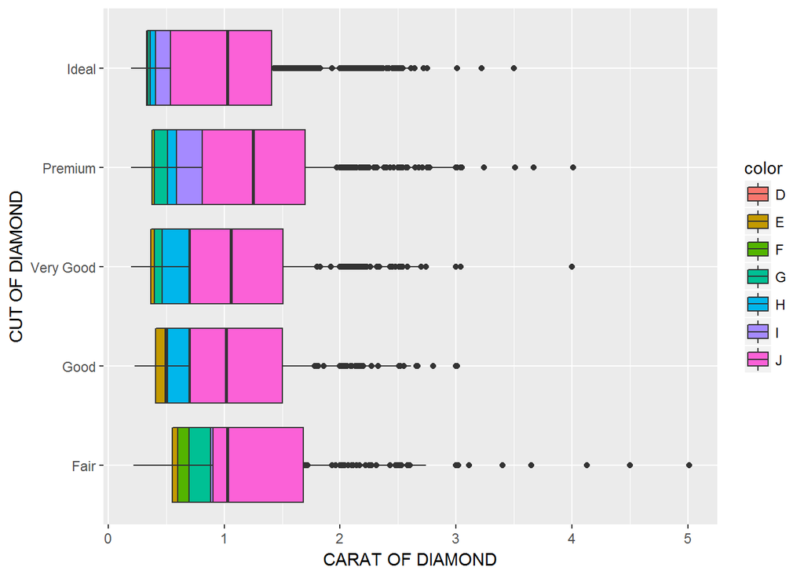

```r
  ggplot(data = diamonds) +
    geom_boxplot(mapping = aes(x = cut, y = carat, fill = color), position = "identity") +
    xlab("CUT OF DIAMOND") +
    ylab("CARAT OF DIAMOND") +
    coord_flip()
```

3. To me, when the colors are all in the same area, it doesn’t provide much information. I have taken out the position argument and this way we can see how each color compares.

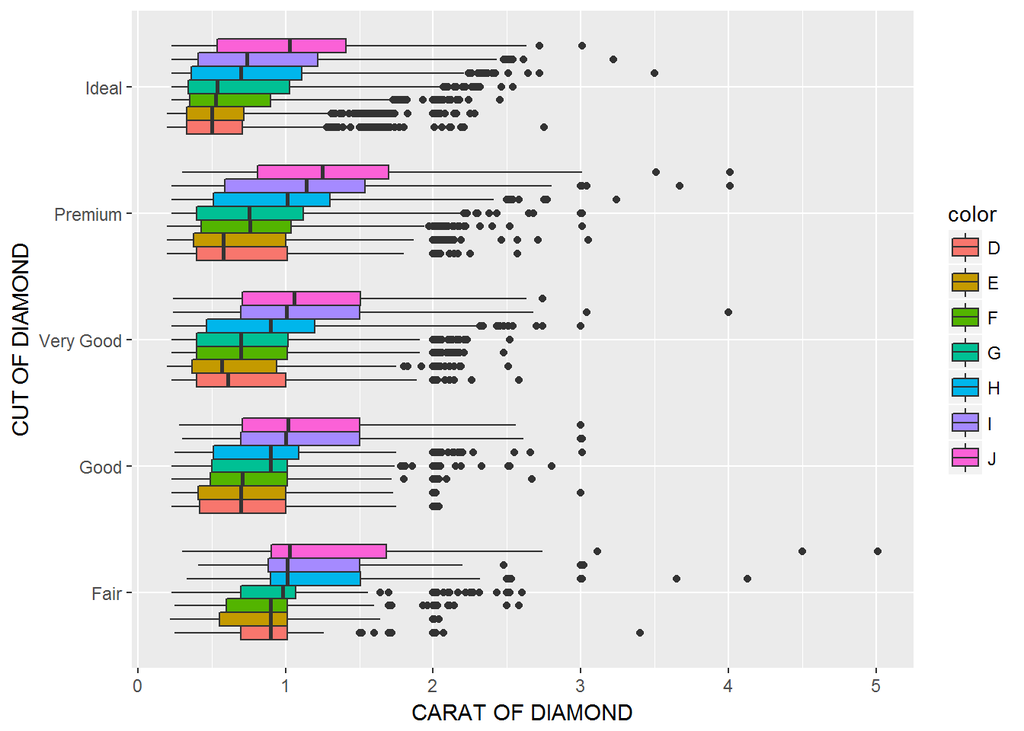

```r
  ggplot(data = diamonds) +
    geom_boxplot(mapping = aes(x = cut, y = carat, fill = color)) +
    xlab("CUT OF DIAMOND") +
    ylab("CARAT OF DIAMOND") +
    coord_flip()
```

### Data munging and wrangling

1. I would say this data is not tidy. We need to spread out the type column.

```r
table2 %>%
  spread(key = type, value = count)
```

```
## # A tibble: 6 x 4
##   country      year  cases population
##   <chr>       <int>  <int>      <int>
## 1 Afghanistan  1999    745   19987071
## 2 Afghanistan  2000   2666   20595360
## 3 Brazil       1999  37737  172006362
## 4 Brazil       2000  80488  174504898
## 5 China        1999 212258 1272915272
## 6 China        2000 213766 1280428583
```

```
diamonds %>%
  mutate(price_per_carat = price / carat)
```

3. The n column is the amount of diamonds in each cut category, and proportion is the proportion when compared to all the cuts together.

```r
diamonds %>%
  filter(price > 10000 & carat < 1.5) %>%
  count(cut) %>%
  mutate(proportion = n / sum(n))
```

```
## # A tibble: 5 x 3
##   cut           n proportion
##   <ord>     <int>      <dbl>
## 1 Fair          4    0.00480
## 2 Good         17    0.0204
## 3 Very Good   155    0.186
## 4 Premium     173    0.207
## 5 Ideal       485    0.582
```

- These results make sense to me because as we are filtering only diamonds that cost over $10,000 while having a carat under 1.5, this means that the cut must be a higher caliber to justify the price.
- I would say perhaps we should be wary of the Fair numbers as there are not too many of them.

### EDA

1. It appears that the time period is from 1/1/2000 - 7/31/2015.

```r
txhousing %>%
  group_by(year, month) %>%
  summarise()
```

```
## # A tibble: 187 x 2
## # Groups:   year [?]
##     year month
##    <int> <int>
##  1  2000     1
##  2  2000     2
##  3  2000     3
##  4  2000     4
##  5  2000     5
##  6  2000     6
##  7  2000     7
##  8  2000     8
##  9  2000     9
## 10  2000    10
## # ... with 177 more rows
```

2. There are 46 cities represented.

```r
length(unique(txhousing$city))
```

```
## [1] 46
```

3. Houston in July 2015 had the most sales at 8945 sales.

```r
txhousing %>%
  arrange(desc(sales))
```

```
## # A tibble: 8,602 x 9
##    city     year month sales     volume median listings inventory  date
##    <chr>   <int> <int> <dbl>      <dbl>  <dbl>    <dbl>     <dbl> <dbl>
##  1 Houston  2015     7  8945 2568156780 217600    23875      3.40  2016
##  2 Houston  2006     6  8628 1795898108 155200    36281      5.60  2006
##  3 Houston  2013     7  8468 2168720825 187800    21497      3.30  2014
##  4 Houston  2015     6  8449 2490238594 222400    22311      3.20  2015
##  5 Houston  2013     5  8439 2121508529 186100    20526      3.30  2013
##  6 Houston  2014     6  8391 2342443127 211200    19725      2.90  2014
##  7 Houston  2014     7  8391 2278932511 199700    20214      3.00  2014
##  8 Houston  2014     8  8167 2195184825 202400    20007      2.90  2015
##  9 Houston  2013     8  8155 2083377894 186700    21366      3.30  2014
## 10 Houston  2006     5  8040 1602621368 151200    35398      5.50  2006
## # ... with 8,592 more rows
```

4. I think there is a positive correlation between sales and listings. I think the more listings there are, the more sales there will be. As you can see in the plot below, there is a positive correlation.

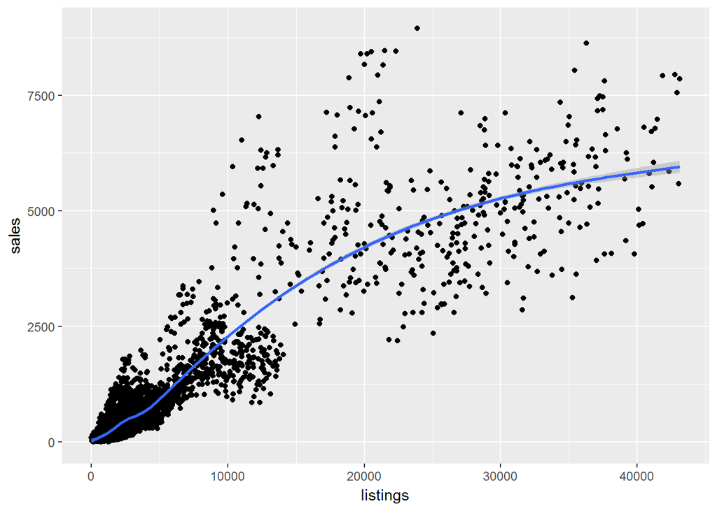

```r
ggplot(data = txhousing) +
  geom_point(mapping = aes(x = listings, y = sales)) +
  geom_smooth(mapping = aes(x = listings, y = sales))
```

5. Please refer to the table below, in the Proportion column.

```r
txhousing %>%
  group_by(city) %>%
  count(NA_Count = sum(is.na(sales))) %>%
  mutate(Proportion = NA_Count / n)
```

```
## # A tibble: 46 x 4
## # Groups:   city [46]
##    city                  NA_Count     n Proportion
##    <chr>                    <int> <int>      <dbl>
##  1 Abilene                      0   187     0
##  2 Amarillo                     0   187     0
##  3 Arlington                    0   187     0
##  4 Austin                       0   187     0
##  5 Bay Area                     0   187     0
##  6 Beaumont                     0   187     0
##  7 Brazoria County             14   187     0.0749
##  8 Brownsville                  2   187     0.0107
##  9 Bryan-College Station        0   187     0
## 10 Collin County                0   187     0
## # ... with 36 more rows
```

- I didn’t really understand this question, but it doesn’t appear the distribution is any different if you `group_by` city or not.

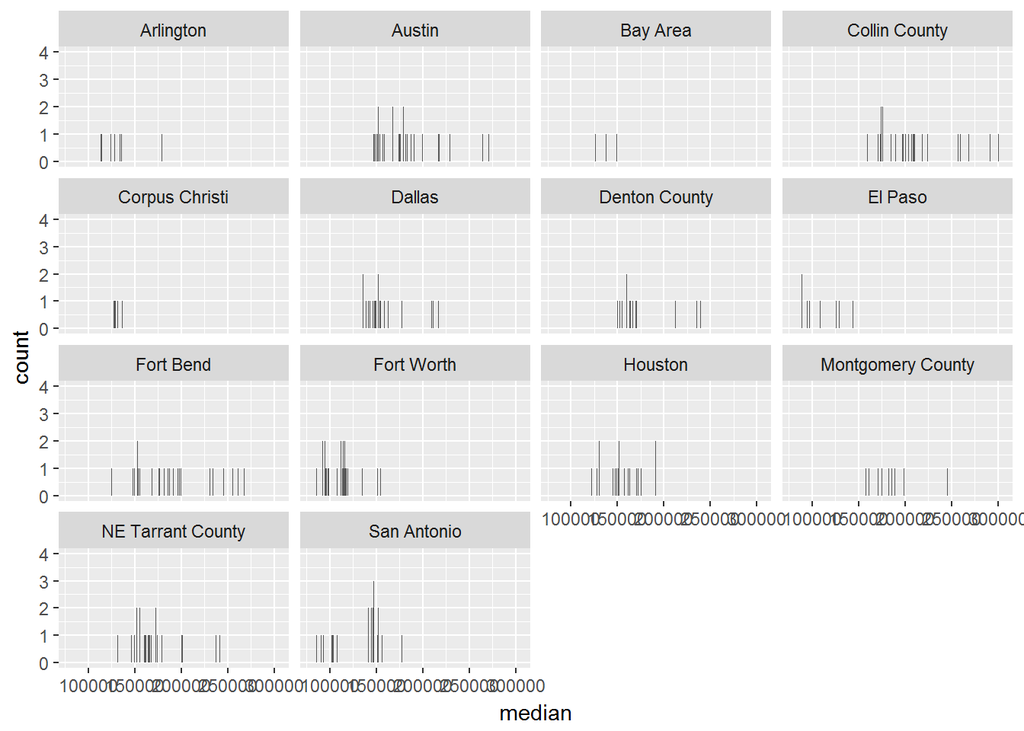

```r
txhousing %>%
  filter(sales > 500) %>%
  group_by(city) %>%
  ggplot() +
  geom_bar(mapping = aes(median)) +
  facet_wrap(~city)
```

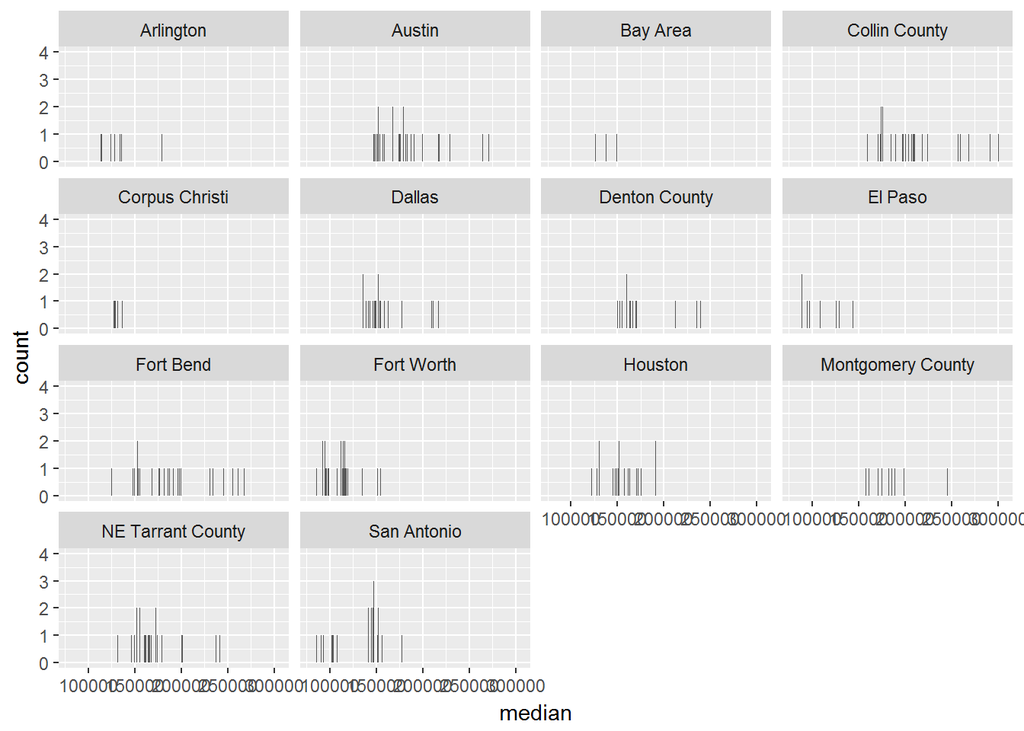

```r
txhousing %>%
  filter(sales > 500) %>%
  ggplot() +
  geom_bar(mapping = aes(median)) +
  facet_wrap(~city)
```